# Sistemas de Ecuaciones en R

Alejandro Alonso Membrilla

En este cuaderno vamos a mostrar una serie de ejemplo para tratar y resolver sistemas de ecuaciones lineales y no lineales utilizando R.

### Sistemas lineales

Un sistema de ecuaciones lineal puede representarse mediante una matriz (de coeficientes) y un vector (de términos independientes). Usaremos los ejemplos siguientes, que definirán un sistema compatible determinado, otro incompatible, y otro compatible indeterminado respectivamente:

```r
A1 <- matrix(c(1, 2, -1, 2), 2, 2)
b1 <- c(2,1)

A2 <- matrix(c(1, 2, -1, 2, 1, 2), 3, 2)
A2 <- matrix(c(1, 2, 1, -1, 2, -1), 3, 2)
b2 <- c(2,1,1)

A3 <- matrix(c(1, 2, 1, 2), 2, 2)
b3 <- c(1,2)
```

Podemos visualizar las ecuaciones de los sistemas anteriores mediante el comando showEqn() de R:

```r
#install.packages("matlib")
#NOTA: puede necesitar tener instaladas las librerías gráficas para desarrolladores (en linux las más comunes son libglu1-mesa-dev freeglut3-dev mesa-common-dev)
library("matlib")
```

```r
#Sistema compatible determinado
showEqn(A1, b1)
```

```
1*x1 - 1*x2  =  2
2*x1 + 2*x2  =  1
```

```r
#Sistema incompatible
showEqn(A2, b2)
```

```
1*x1 - 1*x2  =  2
2*x1 + 2*x2  =  1
1*x1 - 1*x2  =  1
```

```r
#Sistema compatible indeterminado
showEqn(A3, b3)
```

```
1*x1 + 1*x2  =  1
2*x1 + 2*x2  =  2
```

De la misma forma, es posible visualizar las rectas definidas por cada ecuación de forma conjunta usando el comando plotEqn():

```
  x[1] - 1*x[2]  =  2
2*x[1] + 2*x[2]  =  1
```

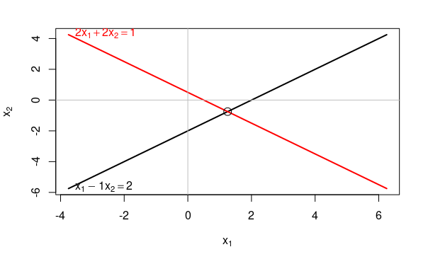

```r
plotEqn(A1, b1)
```

```
  x[1] - 1*x[2]  =  2
2*x[1] + 2*x[2]  =  1
  x[1] - 1*x[2]  =  1
```

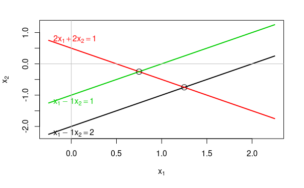

```r
plotEqn(A2, b2)
```

```
  x[1]   + x[2]  =  1
2*x[1] + 2*x[2]  =  2
```

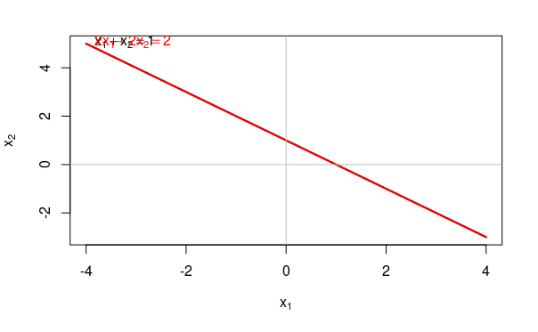

```r
plotEqn(A3, b3)
```

Finalmente, probamos a resolver cada sistema.

```r
#Envolvemos cada llamada a solve con try() para evitar que la ejecución aborte si encuentra un error
s1 <- try(solve(A1,b1))
s2 <- try(solve(A2,b2))
```

```
Error in solve.default(A2, b2) : 'a' (3 x 2) debe ser cuadrada
```

```r
s3 <- try(solve(A3,b3))
```

```
Error in solve.default(A3, b3) :
  Lapack routine dgesv: system is exactly singular: U[2,2] = 0
```

```r
print(s1)
```

```
[1]  1.25 -0.75
```

Como era de esperar, los sistemas definidos por A2|b2 y A3|b3 generan errores, derivados de que la matriz no sea cuadrada o tenga determinante 0.

### Sistemas no lineales

En este caso utilizaremos la biblioteca ‘nleqslv’ de CRAN, que resuelve el sistema numéricamente mediante el método de Broyden o de Newton (para más información, consultar la [documentación](https://cran.r-project.org/web/packages/nleqslv/nleqslv.pdf)). Para su correcto funcionamiento debemos indicarle una solución inicial (puede ser aleatoria) y un vector de funciones que aplicar sobre la variable x de la misma dimensión que esta. Vemos un ejemplo a continuación:

```r
#install.packages("nleqslv")
library("nleqslv")
```

```r
#Una solución es (1 1)
fn <- function(x) {
  y <- numeric(2)
  y[1] <- x[1]^2 + x[2]^2 - 2
  y[2] <- exp(x[1]-1) + x[2]^3 - 2
  y
}

xstart <- c(2,0.5)

#nleqslv(xstart, fn, control=list(btol=.01))
s <- nleqslv(xstart, fn)
#Solución al sistema
print(s$x)
```

```
[1] 1 1
```